# DH 2022 Notebook

## Project

This notebook documents my exploratory analysis of several early twentieth-century US immigrant autobiographical narratives using the Syuzhet package to model narrative shape on an affective basis.

## Get First Text

- Set working directory

```r
setwd("/Users/rodrigue8/Documents/GitHub/modeling-imm-nar")
```

- load Syuzhet

```r
library(syuzhet)
```

- Load Antin text.

```r
antin_text <- get_text_as_string("corpus/Antin22.txt")
```

- Use Syuzhet’s sentence parser to create a sentence vector. Length: 5695.

```r
antin_sentences <- get_sentences(antin_text)
```

- Examine vector to determine further cleaning of front/back material. Back material includes glossary beginning at line 5422.
- Create new sentence vector without glossary.

```r
antin_no_gloss_sentences <- antin_sentences[1:5421]
```

I ran default syuzhet lexicon first to try it out. I created a data frame to quicly compare sentence text and score.

```r
antin_no_gloss_sentence_scores_sy <- get_sentiment(antin_no_gloss_sentences, method="syuzhet")
antin_compare_sy_sent <- data.frame(antin_no_gloss_sentence_scores_sy, antin_no_gloss_sentences)
```

## Initial valdiation

Run all four Syuzhet lexicons.

```r
library(syuzhet)
antin_no_gloss_sentence_scores_sy <- get_sentiment(antin_no_gloss_sentences, method="syuzhet")
antin_no_gloss_sentence_scores_afinn <- get_sentiment(antin_no_gloss_sentences, method="afinn")
antin_no_gloss_sentence_scores_bing <- get_sentiment(antin_no_gloss_sentences, method="bing")
antin_no_gloss_sentence_scores_nrc <- get_sentiment(antin_no_gloss_sentences, method="nrc", lang="english")
```

I then used simple_plot to compare different smoothing methods for Syuzhet lexicon scores.

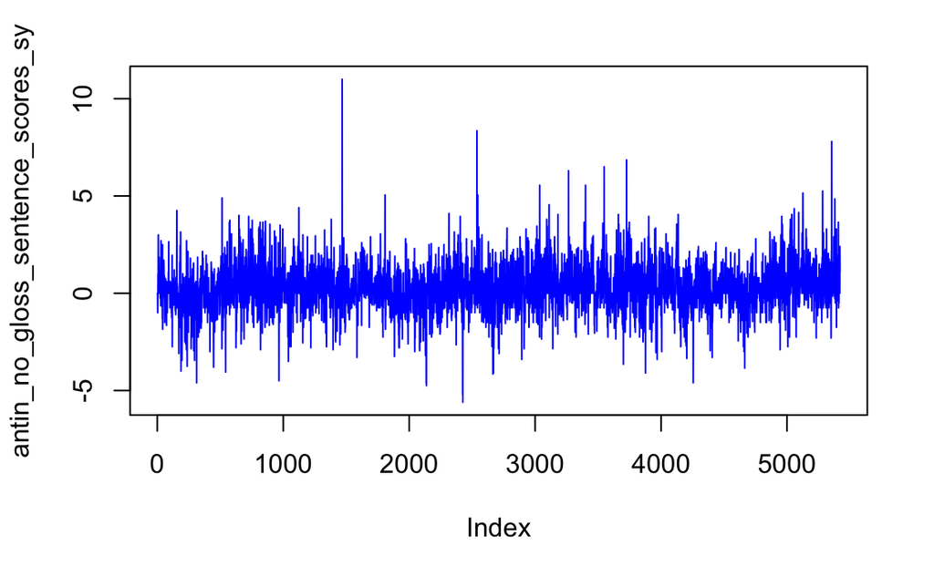

```r
plot(antin_no_gloss_sentence_scores_sy, type= "l", col = "blue")
```

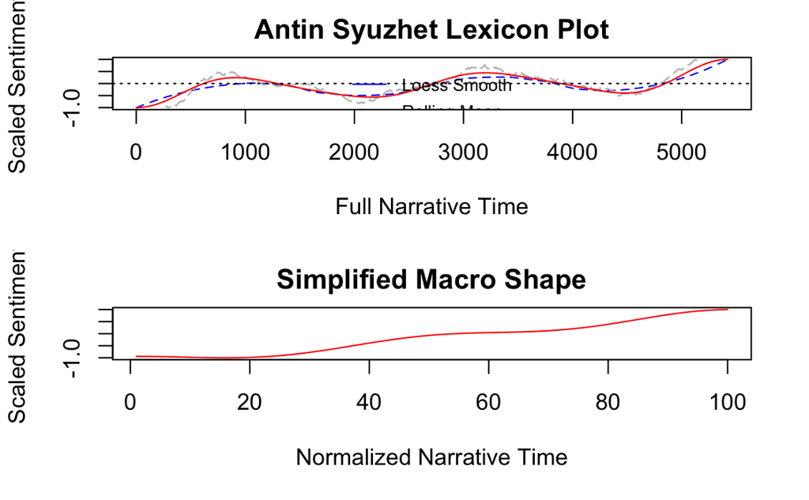

```r
simple_plot(antin_no_gloss_sentence_scores_sy, title = "Antin Syuzhet Lexicon Plot",
  legend_pos = "top",
  lps = 10,
  window = 0.1)
```

I then proceeded to do the same using VADER. This produced a warning message, but it did not appear to affect results. I got the expected number of “observations” ie sentence scores.

```r
library(vader)
antin_vader_sentence_scores <- vader_df(antin_no_gloss_sentences)
```

After a bunch of fails, I realized that in order to visualize just the sentence scores, I would need to extract the “compound” column as a vector.

```r
antin_vader_vec <-antin_vader_sentence_scores$compound
plot(antin_vader_vec, type="l", main="Antin Sentiment Using Vader", xlab="Narrative Time", ylab="Emotional Valence", col="red")
simple_plot(antin_vader_vec)
```

[output not shown]

Isolating from the simple_plot function a function to plot only rolling mean visualization for middle reading as demonstrated by Elkins & Chun:

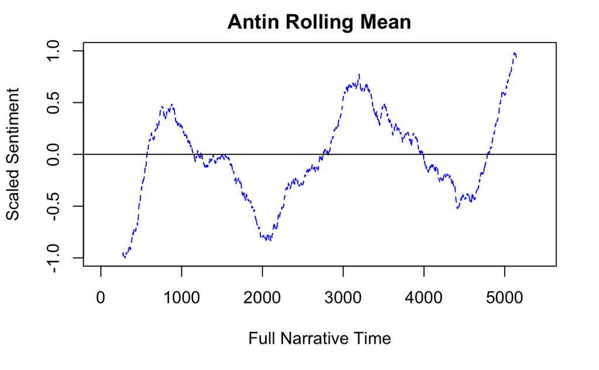

```r
rolling_plot <- function (raw_values, title = "Syuzhet Plot", legend_pos = "top", lps=10, window = 0.1){
  wdw <- round(length(raw_values) * window)
  rolled <- rescale(zoo::rollmean(raw_values, k = wdw, fill = 0))
  half <- round(wdw/2)
  rolled[1:half] <- NA
  end <- length(rolled) - half
  rolled[end:length(rolled)] <- NA
  graphics::plot(rolled, type = "l", ylim = c(-1, 1), main = title, xlab = "Full Narrative Time", ylab = "Scaled Sentiment", col="blue", lty = 2)
  abline(h=0)
}
rolling_plot(antin_no_gloss_sentence_scores_sy, title = "Antin Rolling Mean")
```

```r
compare_rolling <- function (raw_values, window = 0.1) {
  wdw <- round(length(raw_values) * window)
  rolled <- rescale(zoo::rollmean(raw_values, k = wdw, fill = 0))
  half <- round(wdw/2)
  rolled[1:half] <- NA
  end <- length(rolled) - half
  rolled[end:length(rolled)] <- NA
  data.frame(rolled)
}

antin_rolling_compare <- compare_rolling(antin_no_gloss_sentence_scores_sy)
```

Also plotting get percentage values, as Hoyeol Kim suggests.

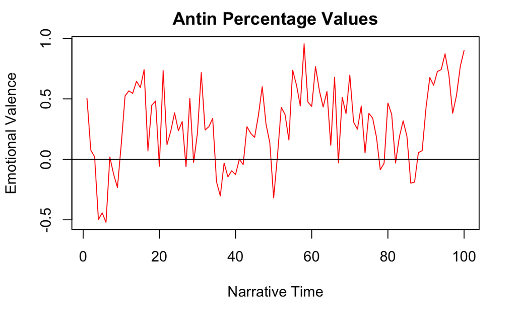

```r
antin_per_val <- get_percentage_values(antin_no_gloss_sentence_scores_sy, bins = 100)
#adding this to easily browse results
antin_compare_per_val <- cbind(antin_per_val)
plot(antin_per_val, type="l",
  main="Antin Percentage Values",
  xlab = "Narrative Time",
  ylab= "Emotional Valence",
  col = "red")
abline(h=0)
```

With default settings, these tools seem to contradict each other: percentage values seems to spend more time in positive territory while rolling mean suggests more time in negative.

Taking a look at summary:

```r
mean(antin_no_gloss_sentence_scores_sy)
```

```
[1] 0.2826877
```

```r
summary(antin_no_gloss_sentence_scores_sy)
```

```
   Min. 1st Qu.  Median    Mean 3rd Qu.    Max.
-5.6000 -0.2500  0.0500  0.2827  0.8000 11.0000
```

```r
mean(antin_per_val)
```

```
[1] 0.2826852
```

```r
summary(antin_per_val)
```

```
    Min.  1st Qu.   Median     Mean  3rd Qu.     Max.
-0.52130  0.02407  0.31019  0.28269  0.52500  0.95556
```

## Modeling additional texts

### Bok

I thought I was going to do Steiner next, but the process of cleaning up the OCR made me hesitant. Then I remembered that there were other texts in Gutenberg. So I’m going to start with those.

Load Bok

```r
bok_text <- get_text_as_string("bok22.txt")
```

Parse into sentences, get syuzhet scores, simple plot.

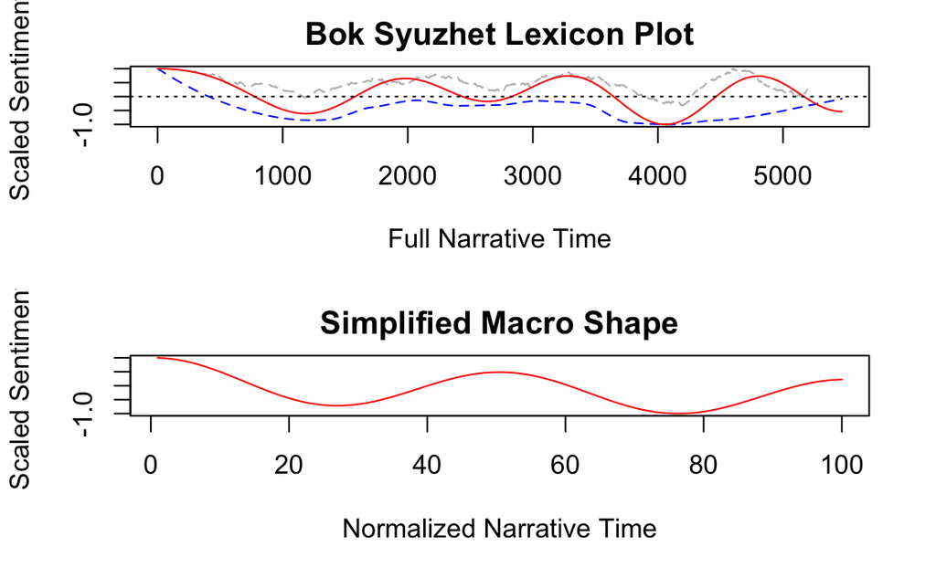

```r
bok_sentences <- get_sentences(bok_text)
bok_sentence_scores_sy <- get_sentiment(bok_sentences, method="syuzhet")
bok_compare_sy_sent <- cbind(bok_sentences, bok_sentence_scores_sy)
simple_plot(bok_sentence_scores_sy, title = "Bok Syuzhet Lexicon Plot",
  legend_pos = "top",
  lps = 10,)
```

Let’s speed this up and do the rest in single chunks.

### Riis

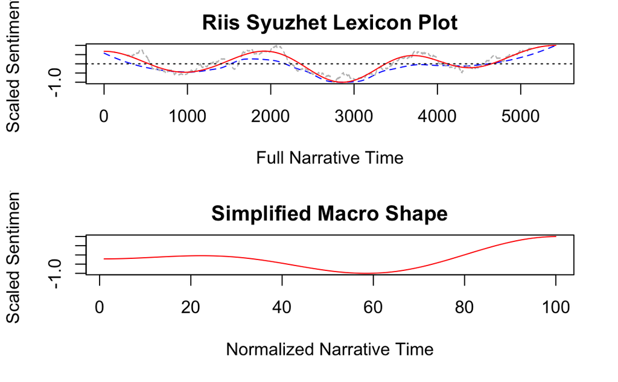

```r
riis_text <- get_text_as_string("riis22.txt")
riis_sentences <- get_sentences(riis_text)
riis_sentence_scores_sy <- get_sentiment(riis_sentences, method="syuzhet")
riis_compare_sy_sent <- cbind(riis_sentences, riis_sentence_scores_sy)
simple_plot(riis_sentence_scores_sy, title = "Riis Syuzhet Lexicon Plot",
  legend_pos = "top",
  lps = 10,)
```

### Pupin

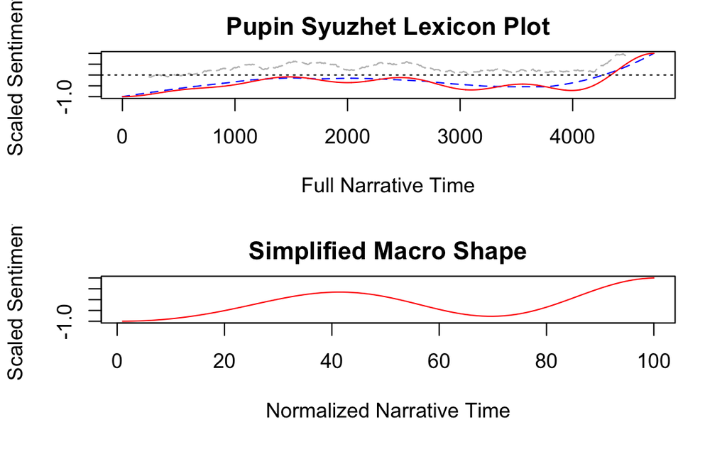

```r
pupin_text <- get_text_as_string("pupin22.txt")
pupin_sentences <- get_sentences(pupin_text)
pupin_sentence_scores_sy <- get_sentiment(pupin_sentences, method="syuzhet")
pupin_compare_sy_sent <- cbind(pupin_sentences, pupin_sentence_scores_sy)
simple_plot(pupin_sentence_scores_sy, title = "Pupin Syuzhet Lexicon Plot",
  legend_pos = "top",
  lps = 10,)
```

## Scraps

This doesn’t work yet, but I want a way to look at all the different values generated for the rolling mean.

```r
compare_rolling <- function (raw_values, window = 0.1) {
  wdw <- round(length(raw_values) * window)
  rolled <- rescale(zoo::rollmean(raw_values, k = wdw, fill = 0))
  #half <- round(wdw/2)
  #rolled[1:half] <- NA
  #end <- length(rolled) - half
  #rolled[end:length(rolled)] <- NA
  data.frame(rolled)
}

antin_rolling_compare <- compare_rolling(antin_no_gloss_sentence_scores_sy)
```

I also want a way to plot all four lexicons using rolling mean on the same plot, which also doesn’t work yet:

```r
rolling_plot(antin_no_gloss_sentence_scores_sy)
line(antin_no_gloss_sentence_scores_afinn)
line(antin_no_gloss_sentence_scores_bing)
line(antin_no_gloss_sentence_scores_nrc)
```